# Disparate views of disparity

Thomas Guillerme

2017-12-11

```r
library(dispRity)
source("../Functions/fuzzy.sort.data.R")
source("../Functions/plot.data.R")
```

# Data

## Data collection from google scholars

I collected the data from the 500 first Google Scholar results for the key words “morphological disparity” per order of appearance (accessed 1st of November 2017). This resulted in 232 relevant papers for which I collected:

- The focal biological group
- The type of data (3D landmarks, discrete data, etc…)
- Whether the full organism was used or not.
- How was the morphospace explicitly defined?
- How was disparity explicitly defined?
- Which test was applied for testing hypothesis?
- Was phylogeny taken into account?

In the other 268 papers disparity was mentioned but not measured. This happened for papers falling in the following categories:

- Out of topic
- Morphological descriptions
- Review paper
- Paper not accessible (broken link or paywall)
- Citation only

Additionally I collected the number of matches per year from 1960 to 2016 for the terms “morphological disparity” both in the text (fuzzy matching) or in the title (exact matching).

## Data wrangling

I then categorised the data as follows.

```r
## Reading the data
cleaned_data <- readRDS("../Data/Processed/cleaned_data.Rda")
search_results <- read.csv("../Data/GoogleSearch_occurences.csv", stringsAsFactors = FALSE)

## Extracting the cleaned data
factors <- cleaned_data$factors
data <- cleaned_data$data
```

# Occurrences of morphological disparity papers

This first analysis just shows that disparity analysis in morphology are steadily and rapidly increasing since the 2000s:

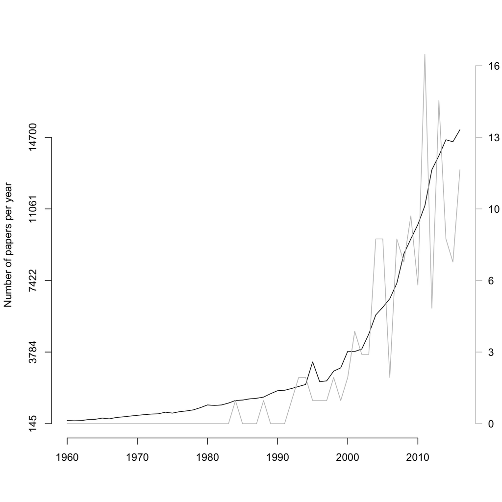

```r
## Selecting the right data
disparity_fuzzy <- search_results[-c(1:2, 60:65),3]
disparity_exact <- search_results[-c(1:2, 60:65),2]

## Number of papers
# pdf("../Writing/Figures/GoogleScholarOccurences.pdf", width = 8, height = 8)
op <- par(bty = "n")
plot(seq(from = 1960, to = 2016), rev(disparity_fuzzy)/search_results[1,3], type = "l", xlab = "", ylab = "Number of papers per year", ylim = c(0, 0.1), yaxt = "n")
lines(seq(from = 1960, to = 2016), rev(disparity_exact)/search_results[1,2], type = "l", col = "grey")
## Adding the axis
axis(2, at = seq(from = 0, to = 0.08, by = 0.02), labels = round(seq(from = min(disparity_fuzzy), to = max(disparity_fuzzy), length.out = 5)) )
axis(4, at = seq(from = 0, to = 0.1, by = 0.02), labels = round(seq(from = min(disparity_exact), to = max(disparity_exact), length.out = 6)), col = "grey", las = 2)
```

```r
par(op)
# dev.off()
```

Not much to say here but that it is a trendy topic!

# Disparate views of disparity

Disparity methods comes in all flavours!

## Variable distribution

What is the proportion of use for each method?

```r
## Plotting the results
pdf("../Writing/Figures/MethodsProportions.pdf", width = 12, height = 12)
op <- par(mfrow = c(2, 2), bty = "n")
for(factor in c(2,4,5,6)) {
    plot.data(fuzzy.sort.data(data[,factor], factors[[factor]]), proportion = TRUE, ylim = c(0, 100), main = names(factors)[[factor]])
}
par(op)
dev.off()
```

Methods seem to full in three main categories:

```r
## Methods types table (empty)
methods_types <- matrix(NA, nrow = 3, ncol = 6, dimnames = list(c("Claddis", "geomorph", "dtt"), c(names(factors)[-1])))

## Filling the table
methods_types[,1] <- c("discrete", "landmarks", "continuous")
methods_types[,2] <- c("yes", "no", "yes")
methods_types[,3] <- c("PCO", "PCA", "\"pairwise matrix\"")
methods_types[,4] <- c("variance", "distance", "pairwise distance")
methods_types[,5] <- c("variable", "anova", "models")
methods_types[,6] <- c("no", "sometimes", "yes")

knitr::kable(methods_types)
```

|  | data_type | full_organism | morphospaces | disparity | tests | phylogeny |
| --- | --- | --- | --- | --- | --- | --- |
| Claddis | discrete | yes | PCO | variance | variable | no |
| geomorph | landmarks | no | PCA | distance | anova | sometimes |
| dtt | continuous | yes | “pairwise matrix” | pairwise distance | models | yes |

## A disparity-space?

Multivariate data? Let’s analysis it using disparity!

But first, a bit of cleaning

```r
## Removed columns
removed_factors <- c(1)

## Removing factors from the data
multi_data <- apply(data[,-removed_factors], 2, as.character)

## Replace NAs by "-"
multi_data <- ifelse(is.na(multi_data), "-", multi_data)

## Selecting only the first variable when multiples
multi_data <- gsub(" \\+ .*", "", multi_data)

## Transform the data as numeric
multi_data <- as.list(as.data.frame(multi_data))
multi_data <- lapply(multi_data, as.numeric)
multi_data <- matrix(unlist(multi_data), ncol = ncol(data[,-removed_factors]), byrow = FALSE)

## Make a pairwise matrix
pairwise_data <- vegan::vegdist(multi_data, method = "bray")

## Ordinating the distance matrix
ordinated_data <- stats::cmdscale(pairwise_data, k = sum(unlist(lapply(factors[-removed_factors], length))) - 2)
rownames(ordinated_data) <- seq(1:nrow(data))
#TG: Axis are selected as the number of factors - 2
```

```r
## Get the variance per axis
scree_plot <- dispRity::variances(ordinated_data)
percentages_scree <- round(scree_plot/sum(scree_plot)*100, digit = 2)

## Variance per dimensions
barplot(scree_plot, ylab = "Variance per dimension", xlab = "Dimensions")
```

[output not shown]

## Testing the three categories hypothesis

Setting the data for the three categories hypothesis:

```r
cleaned_data <- readRDS("../Data/Processed/cleaned_data.Rda")

## Get the group variables
Claddis_group_var <- list(factors$data_type[3], factors$morphospaces[2], factors$disparity[c(4,5)])
geomorph_group_var <- list(factors$data_type[c(1,2)], factors$morphospaces[1], factors$disparity[c(2,9)])
dtt_group_var <- list(factors$data_type[4], factors$morphospaces[4], factors$disparity[6])

select.group <- function(data, group) {
    ## Selecting the group variables
    multi.grep <- function(x, pattern, ignore.case = TRUE, ...) {
        ## Finding if the patten matches in x
        is_grep <- unlist(sapply(pattern, grep, x, ignore.case = ignore.case, simplify = FALSE, USE.NAMES = FALSE))
        ## Return true/false
        return(ifelse(length(is_grep) > 0, TRUE, FALSE))
    }

    data_type <- sapply(data[,2], multi.grep, pattern = group[[1]], USE.NAMES = FALSE)
    morphospace <- sapply(data[,4], multi.grep, pattern = group[[2]], USE.NAMES = FALSE)
    disparity <- sapply(data[,5], multi.grep, pattern = group[[3]], USE.NAMES = FALSE)

    all_match <- data_type & morphospace & disparity
    two_match_1 <-  morphospace & disparity
    two_match_2 <-  data_type & disparity
    two_match_3 <-  data_type & morphospace

    return(list("match3" = all_match, "match2" = list(two_match_1, two_match_2, two_match_3), "match1" = list(data_type, morphospace, disparity)))
}

## Select the groups
Claddis_groups <- select.group(data, Claddis_group_var)
geomorph_groups <- select.group(data, geomorph_group_var)
dtt_groups <- select.group(data, dtt_group_var)

## Select the full groups
Claddis_group <- Claddis_groups$match3
geomorph_group <- geomorph_groups$match3
dtt_group <- dtt_groups$match3
no_group <- !(Claddis_group | geomorph_group | dtt_group)

## Create the group variable
groups <- rep(NA, nrow(data))
groups <- ifelse(Claddis_group, "Claddis", groups)
groups <- ifelse(geomorph_group, "geomorph", groups)
groups <- ifelse(dtt_group, "dtt", groups)
groups <- ifelse(no_group, "none", groups)

## Get the groups IDs
Claddis_group_id <- which(Claddis_group)
geomorph_group_id <- which(geomorph_group)
dtt_group_id <- which(dtt_group)
no_group_id <- which(no_group)
```

## Plotting the group’s

```r
col_palette <- c("red", "blue", "green3", "grey")

plot(ordinated_data[,1], ordinated_data[,2], xlab = paste0("PC1 (",percentages_scree[1], "%)"), ylab = paste0("PC2 (",percentages_scree[2], "%)"), pch = 19, col = col_palette[as.factor(groups)])

legend("bottomright", legend = levels(as.factor(groups)), col = col_palette, pch = 19, cex = 0.5)
```

[output not shown]

## Testing the effect of groups

```r
## Creating the custom groups list
groups_list <- list("Claddis" = Claddis_group_id, "geomorph" = geomorph_group_id, "dtt" = dtt_group_id)

## Creating the groups for the pairwise matrix and the ordinated one
pair_matrix <- as.matrix(pairwise_data)
rownames(pair_matrix) <- seq(1:nrow(data))
groups_pair <- custom.subsets(pair_matrix, group = groups_list)
groups_ordi <- custom.subsets(ordinated_data, group = groups_list)

## Effect of groups
vegan::adonis2(pairwise_data ~ group, data = data.frame(matrix(groups, ncol = 1, dimnames = list(seq(1:nrow(data)), c("group")))))

## Effect of groups (individual)
groups_data <- data.frame(cbind(as.factor(Claddis_group), as.factor(geomorph_group), as.factor(dtt_group), as.factor(no_group)))
rownames(groups_data) <- seq(1:nrow(data))
colnames(groups_data) <- c("Claddis", "geomorph", "dtt", "nope")
vegan::adonis2(pairwise_data ~ Claddis + geomorph + dtt + nope, data = groups_data, permutations = 100)
```

[output not shown]

# Supplementary

## Number of papers collected for each parameter

```r
## Get the data for cumulative curves
total_cumulative <- data_raw[,c(1,3)]
#data_type_cumulative <- data_raw[,c(1,4)]

## Transform the cumulative data into binary
results <- grep("-", total_cumulative[,2])
results <- cbind(results, seq(1:length(results)))

plot(add, type = "line", xlab = "Number of Google Scholar matches", ylab = "Number of new entries")
```

## Groups studied

Which groups are studied using disparity analysis?

```r
plot.data(fuzzy.sort.data(data[,1], factors[[1]]), proportion = TRUE, ylim = c(0, 100), main = names(factors)[[1]])
```

[output not shown]